# TS_2

## Time plot

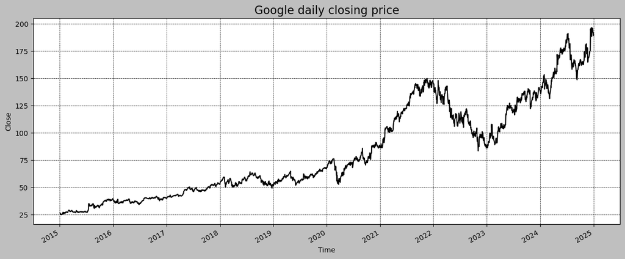

```python
time_plots(google_df,'Close', 'Google daily closing price')
```

```
Seasonal plot: google daily price
```

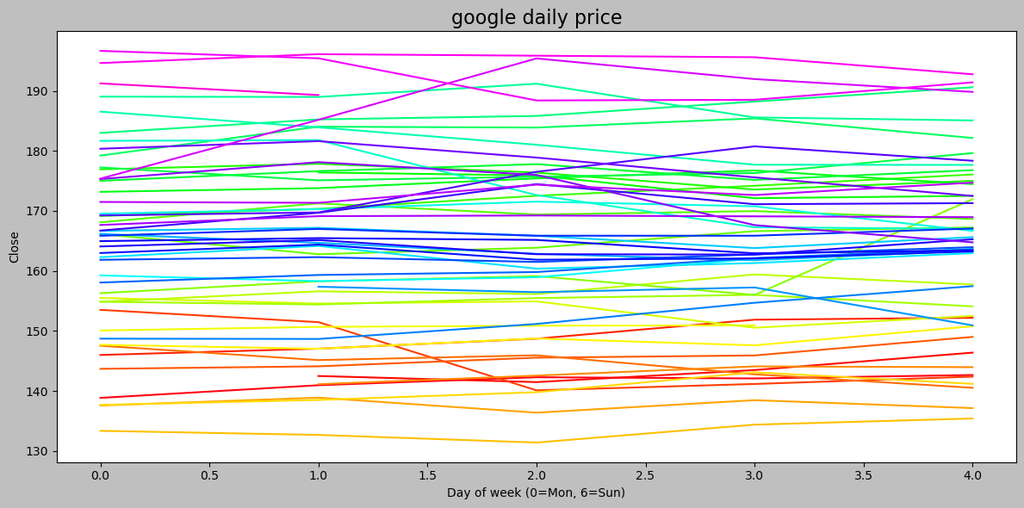

```python
seasonal_plot(
        google_df,
        'Close',
        'google daily price',
        'dayofweek'
    )
```

On this graph there seems to be no really useful information as each line is quite different, there are no patterns.

```
Seasonal plot: google daily price
```

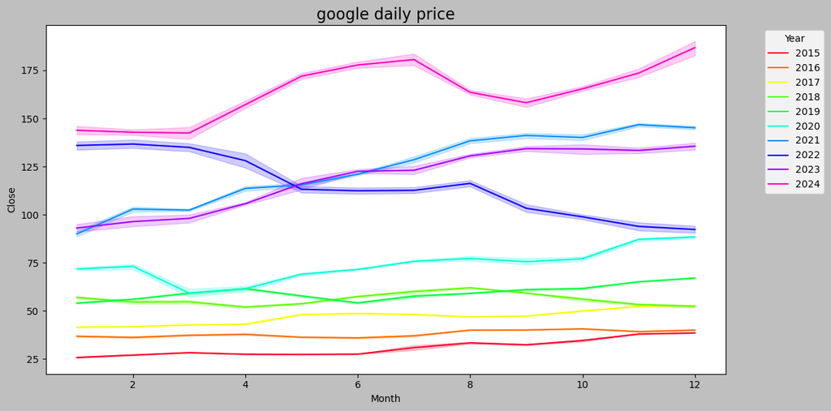

```python
seasonal_plot(
        google_df,
        'Close',
        'google daily price',
        'month'
    )
```

Here we see that the price usually increases every year, but there is something unusual - in 2022 the line goes down.

```
Plotting seasonal subseries: Google daily price subseries by day of week
```

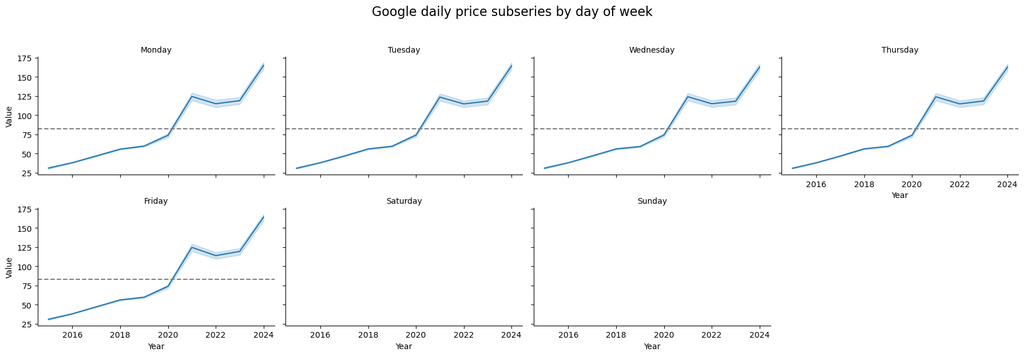

```python
plot_seasonal_subseries(
    google_df,
    'Close',
    'Google daily price subseries by day of week',
    'dayofweek'
)
```

No real useful information here. The graphs are practically the same for different weekdays.

```
Plotting lag plots: Google Stock Lag Plots
```

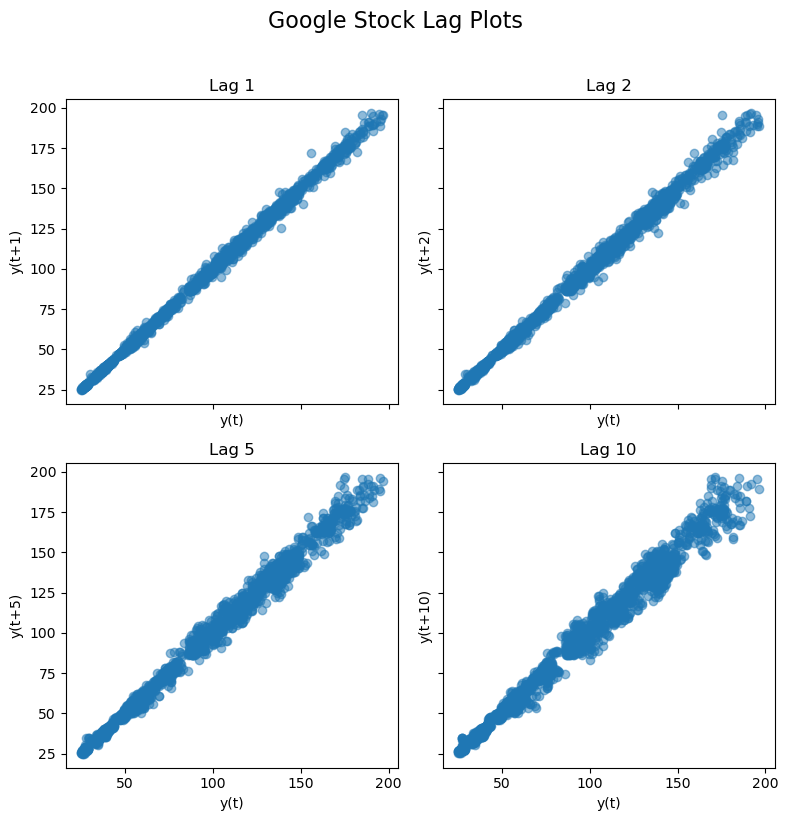

```python
plot_lag(
    google_df,
    'Close',
    'Google Stock Lag Plots',
    lags=[1, 2, 5, 10]
)
```

The graphs here show different lags and we see that they are not very different, though with bigger lag we have more deviations from the initial central line.

```
Plotting lag plots: Google Stock Lag Plots
```

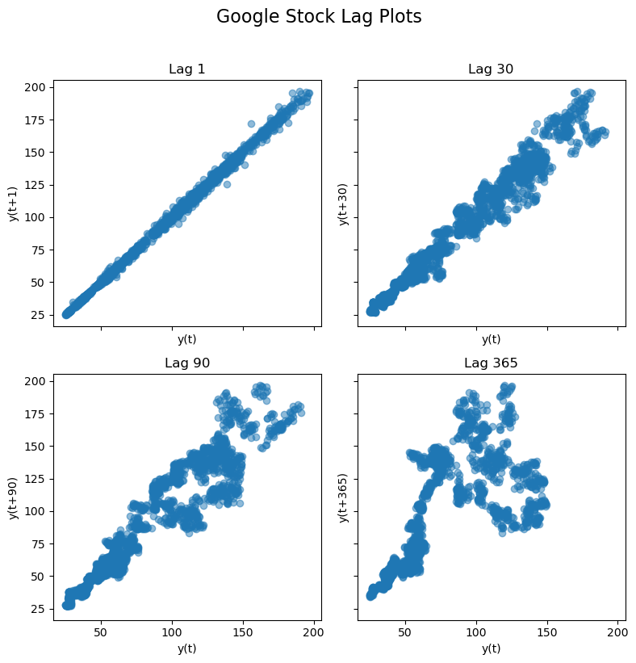

```python
plot_lag(
    google_df,
    'Close',
    'Google Stock Lag Plots',
    lags=[1, 30, 90, 365]
)
```

Here I decided to repeat lag graphs, but this time with bigger lags. As we may see, the bigger the lag - the bigger the deviations. We can make a conclusion that data is more similar with smaller lag and then, after long time especially, it is not really useful for prognosing.

```
Plotting ACF: Google Stock ACF
```

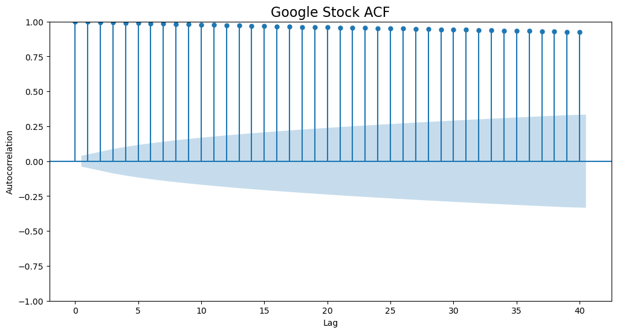

```python
plot_autocorrelation(
        google_df,
        'Close',
        'Google Stock ACF',
        lags=40
    )
```

This graph show gradual decline. It means that Google stock prices have some memory effect meaning recent prices influence future ones, but this effect weakens over time.

## UK air passengers dataset

```python
uk_air_df = load_time_series_data(
    filepath='uk_air_passengers.csv',
    time_column='Date',
    y_column='Passengers',
    delimiter=';',
    date_format='%d. %b %y'
)
```

```
Loading: uk_air_passengers.csv
Successfully loaded and processed uk_air_passengers.csv.

The history saving thread hit an unexpected error (OperationalError('attempt to write a readonly database')).History will not be written to the database.
```

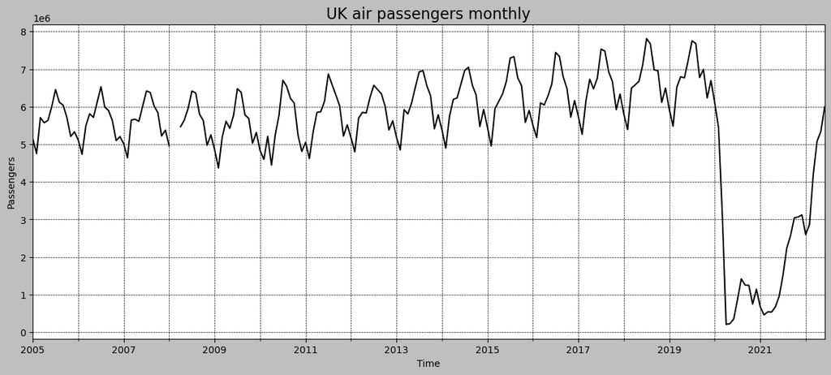

```python
time_plots(uk_air_df, 'Passengers', 'UK air passengers monthly')
```

Here we see that there is definitely seasonality and that in 2020 something happened as the amount of passengers sharply dropped down.

```
Seasonal plot: UK air passengers
```

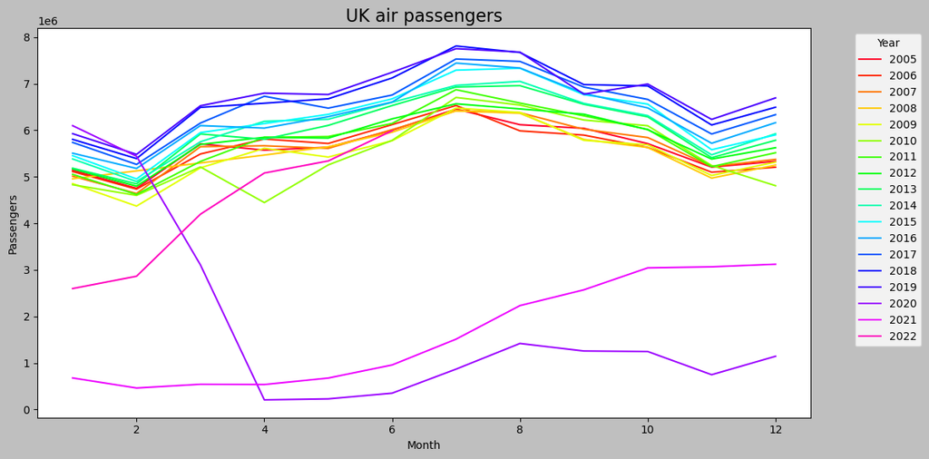

```
Plotting seasonal subseries: UK air passengers subseries by month
```

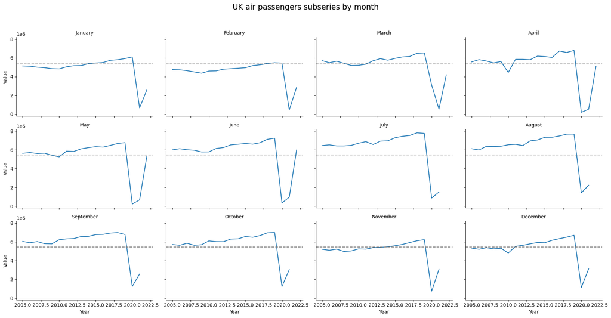

```python
seasonal_plot(
        uk_air_df,
        'Passengers',
        'UK air passengers',
        'month'
    )
plot_seasonal_subseries(
    uk_air_df,
    'Passengers',
    'UK air passengers subseries by month',
    'month'
)
```

On the first graph here we can see that again we have seasonality, which seems to have highest numbers in July and August and a sharp decline in 2020 (Covid-19). From the second plot we see that people seem to travel more in I would call it "summer part of the year" from April to October. Also we see that in April 2010 there is a sharp decline - because of volcano eruption in Iceland atmosphere was too bad. Also the sharp dip in December 2010 was caused by severe, widespread snow and record-low temperatures across the UK and Europe. And there was an economic crisis in 2007-2009, which is also seen on the graphs.

```
Plotting lag plots: UK air passengers lag plots
```

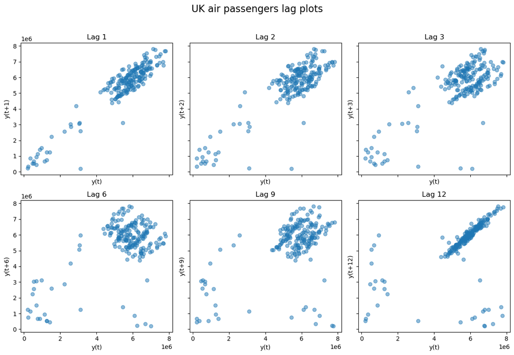

```
Plotting ACF: UK air passengers ACF
```

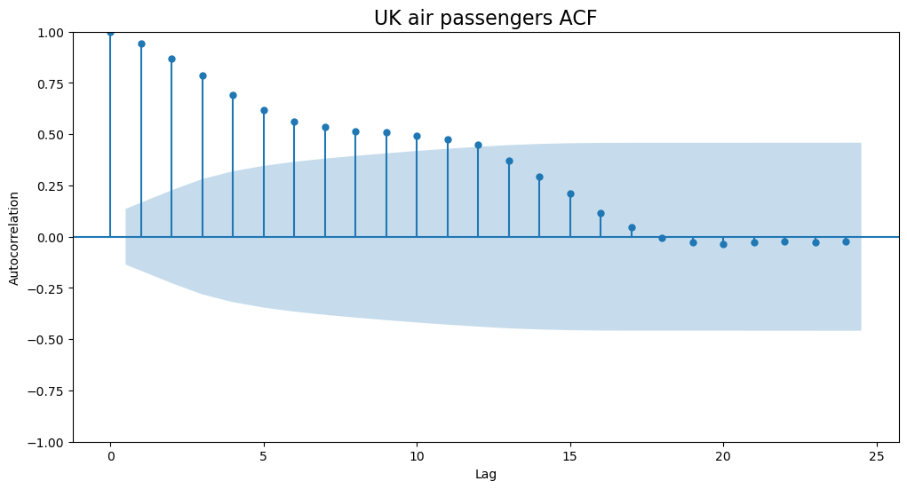

```python
plot_lag(
    uk_air_df,
    'Passengers',
    'UK air passengers lag plots',
    lags=[1, 2, 3, 6, 9, 12]
)

plot_autocorrelation(
    uk_air_df,
    'Passengers',
    'UK air passengers ACF',
    lags=24
)
```

Passengers lag plots show that one month's passenger count is a very strong predictor of the next month's count. The relationship weakens at intermediate lags (like 6 and 9), but then becomes strong and tight again at lag 12. Passengers ACF shows that the lags start very high and decay very slowly. We see a strong trend, meaning the series is non-stationary.

```
Plotting seasonal lag plots: UK air passengers seasonal lag plots
```

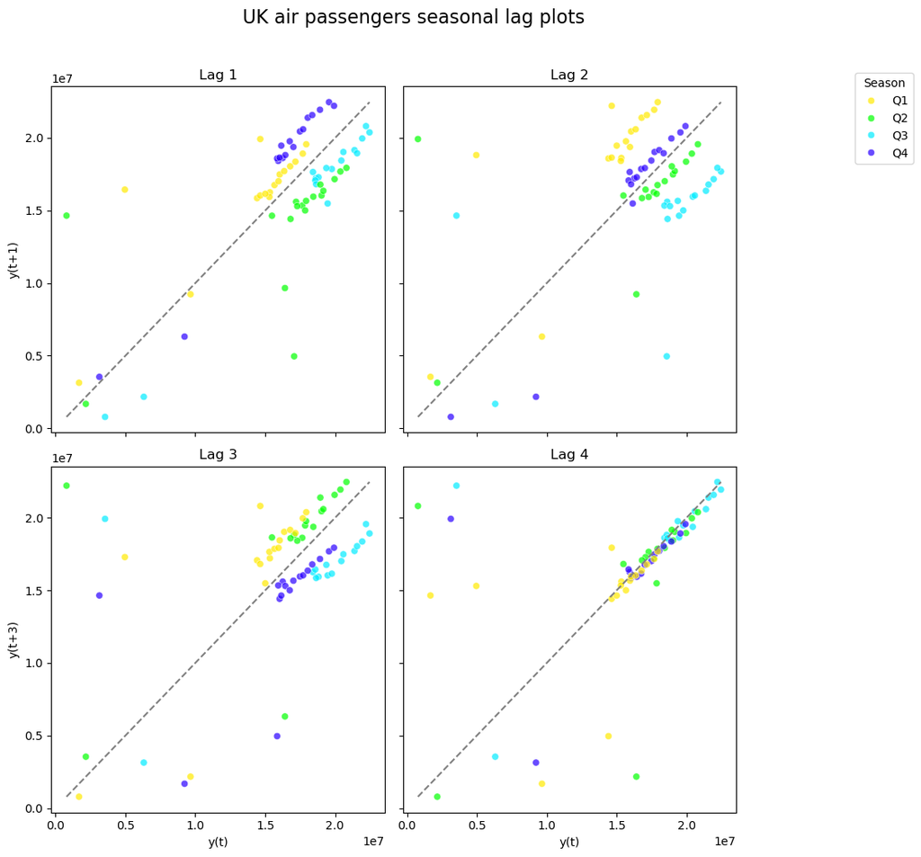

```python
uk_air_quarterly_df = uk_air_df.resample('QE').sum()

plot_seasonal_lag(
        uk_air_quarterly_df,
        'Passengers',
        'UK air passengers seasonal lag plots',
        lags=[1,2, 3, 4],
        period_unit='quarter'
    )
```

This graph reveals a strong upward trend and a powerful yearly seasonal pattern.

## AEP hourly dataset

```python
aep_hourly_df = load_time_series_data(
    filepath='AEP_hourly.csv',
    time_column='Datetime',
    y_column='AEP_MW'
)

aep_daily_df = aep_hourly_df.resample('D').mean()
aep_monthly_df = aep_hourly_df.resample('ME').mean()
aep_quarterly_df = aep_hourly_df.resample('QE').sum()
```

```
Loading: AEP_hourly.csv
Successfully loaded and processed AEP_hourly.csv.
```

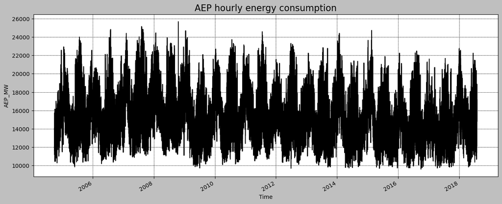

```python
time_plots(aep_hourly_df, 'AEP_MW', 'AEP hourly energy consumption')
```

We can see some seasonality, but the graph is too dense.

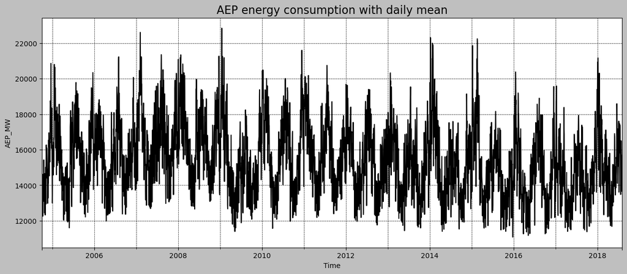

```python
time_plots(aep_daily_df, 'AEP_MW', 'AEP energy consumption with daily mean')
```

We can also see some seasonality, but the graph is too dense. Also the series looks stationary, as it stands around a stable central value (approx. 16,000 MW) without a clear long-term upward or downward trend.

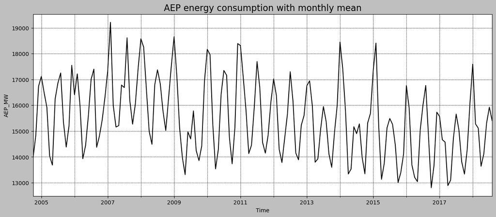

```python
time_plots(aep_monthly_df, 'AEP_MW', 'AEP energy consumption with monthly mean')
```

On this graph we see a double peak pattern - in winter and summer. We also see less energy consumed in summer 2009 and summer 2014.

```
Seasonal plot: AEP daily energy last 52 weeks
```

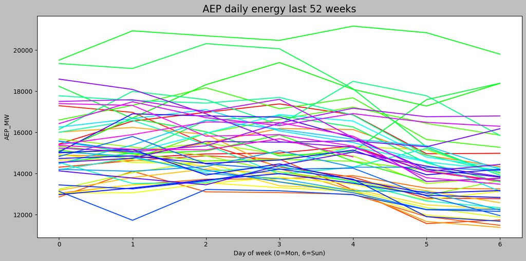

```python
seasonal_plot(
        aep_daily_df,
        'AEP_MW',
        'AEP daily energy last 52 weeks',
        'dayofweek'
    )
```

On this graph we see that clearly on weekends less amount of energy is consumed.

```
Seasonal plot: AEP monthly energy
```

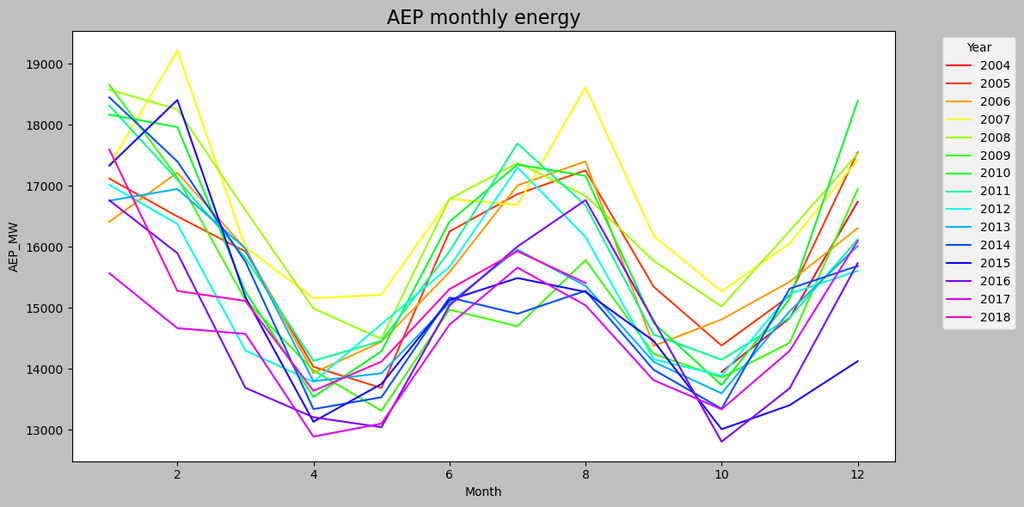

```python
seasonal_plot(
        aep_monthly_df,
        'AEP_MW',
        'AEP monthly energy',
        'month'
    )
```

And again on the seasonal graph we see double-peacked picture.

```
Plotting seasonal subseries: AEP daily energy subseries by day of week
```

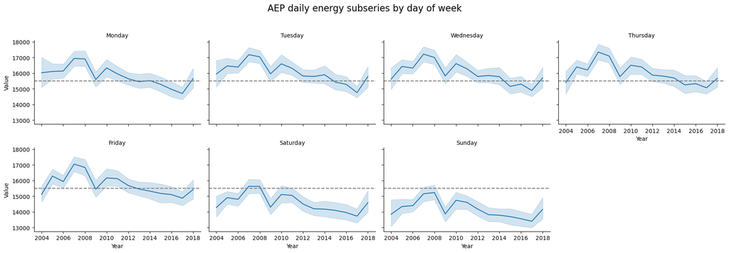

```python
plot_seasonal_subseries(
    aep_daily_df,
    'AEP_MW',
    'AEP daily energy subseries by day of week',
    'dayofweek'
)
```

We can see a downgoing trend and that on weekends the energy consumption is less.

```
Plotting lag plots: AEP Daily Energy Lag Plots
```

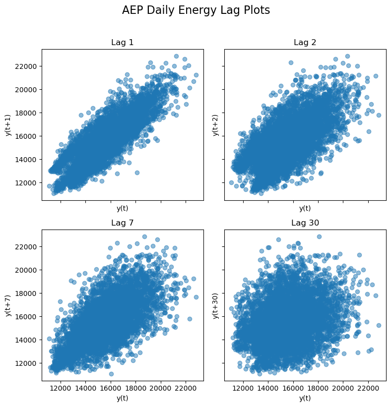

```
Plotting ACF: AEP Daily Energy ACF
```

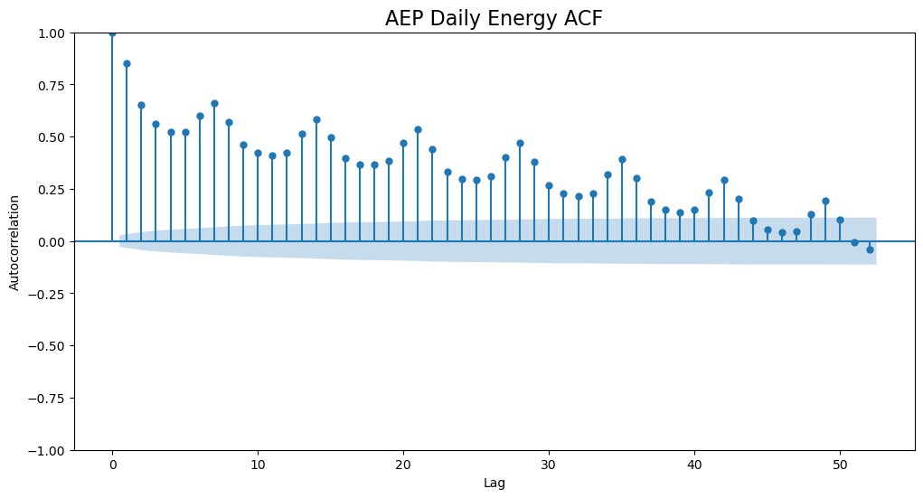

```python
plot_lag(
    aep_daily_df,
    'AEP_MW',
    'AEP Daily Energy Lag Plots',
    lags=[1, 2, 7, 30]
)

plot_autocorrelation(
    aep_daily_df,
    'AEP_MW',
    'AEP Daily Energy ACF',
    lags=52
)
```

```
Plotting seasonal lag plots: UK air passengers seasonal lag plots
```

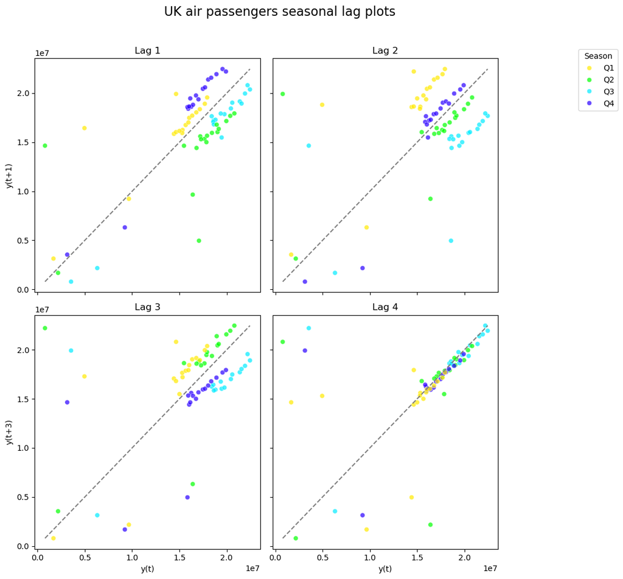

```python
plot_seasonal_lag(
        uk_air_quarterly_df,
        'Passengers',
        'UK air passengers seasonal lag plots',
        lags=[1,2, 3, 4],
        period_unit='quarter'
    )
```

This plot provides clear proof that the time series has both a strong upward trend and a powerful yearly seasonal pattern.

## All US energy regions dataset

```python
all_regions_daily_df = load_and_melt_wide_data(
    filepath='pjm_hourly_est.csv',
    time_column='Datetime',
    resample_freq='D'
)

plot_all_series(
    all_regions_daily_df,
    'All energy regions by daily mean'
)
```

[output not shown]